# Salem_visualization_essay

a guidone

3/24/2017

```r
library(tidyverse)
library(dplyr)
library(lubridate)
library(stringr)
library(forcats)
```

```r
salem_crew <- read_csv("salem_crew.csv")
salem_voyages <- read_csv("salem_voyages.csv")
```

3,307 voyages between 1797-1832 and 15,364 sailors(1797-1832 which have full data sets including date, position, and complexion). however, this doesn’t account for duplicates. could fix by finding code to possibly combine first and last names into one column and then seeing what the difference in totals is. If insignificant total then probably don’t have to worry about it but just note it.

```r
salem_data_joined_birth_year <- salem_crew %>%
  left_join(salem_voyages, "VoyageId") %>%
  select(VoyageId, SortDate, BirthPlace) %>%
  na.omit()

extract_year <- function(x) {
  year_char <- stringr::str_extract(x, "\\d{4}")
  year_int <- as.integer(year_char)
  year_int
}

salem_data_tidy_birth_year <- salem_data_joined_birth_year %>%
  mutate(SortDate, Year = extract_year(salem_data_joined_birth_year$SortDate)) %>%
  select(-SortDate)

salem_data_tidy_birth_year_1797_1832 <- salem_data_tidy_birth_year %>%
  filter(Year >= 1797, Year <= 1832)
```

```r
unique(salem_data_tidy_birth_year_1797_1832$BirthPlace)
```

```
##    [1] "Salem"
##    [2] "Liberty, ME"
##    [3] "Genoa, Italy"
##    [4] "New York"
##    [5] "Boston"
##    [6] "Eastport, ME"
##    [7] "Alexandria, DC"
##    [8] "no proof"
##    [9] "Copenhagen, Denmark"
##   [10] "France"
##   [11] "Portland, ME"
##   [12] "Sydney"
##   [13] "Portsmouth"
##   [14] "Oswego, NY"
##   [15] "Kingston, NY"
```

[output cut: 2381 more lines]

```r
salem_data_tidy_birth_year_1797_1832 %>%
  count(BirthPlace)
```

```
## # A tibble: 2,396 × 2
##                 BirthPlace     n
##                      <chr> <int>
## 1                        ?    28
## 2                    Abany     1
## 3                Abbington     1
## 4                 Aberdeen     2
## 5       Aberdsen, Scotland     1
## 6                 Accomack     4
## 7      Accomack County, MD     1
## 8             Accomack, VA     4
## 9  Accomac, (Virgin Isles)     1
## 10                   Acton     1
## # ... with 2,386 more rows
```

```r
salem_comprehensive_data <- salem_crew %>%
  left_join(salem_voyages, "VoyageId")
```

```r
salem_data_joined_complexion_year <- salem_comprehensive_data %>%
  select(VoyageId, SortDate, BirthPlace, Complexion, Position) %>%
  na.omit()
```

```r
extract_year <- function(x) {
  year_char <- stringr::str_extract(x, "\\d{4}")
  year_int <- as.integer(year_char)
  year_int
}
```

```r
salem_data_tidy_complexion_year <- salem_data_joined_complexion_year %>%
  mutate(SortDate, Year = extract_year(salem_data_joined_complexion_year$SortDate)) %>%
  select(-SortDate)
```

```r
salem_data_tidy_complexion_year_1797_1832 <- salem_data_tidy_complexion_year %>%
  filter(Year >= 1797, Year <= 1832)
```

```r
unique(salem_data_tidy_complexion_year_1797_1832$Complexion)
```

```
##  [1] "Dark"           "Light"          "Black"          "Sallow"
##  [5] "Fair"           "Ruddy"          "Sandy"          "Brown"
##  [9] "Yellow"         "?"              "Dark?"          "Mulatto"
## [13] "Florid"         "Sambo"          "Black (yellow)" "Quadroon"
## [17] "Pale"           "Very Black"     "Bright yellow"  "Negro"
## [21] "Fresh"          "Lambs?"         "Very Dark"      "Colored"
## [25] "Mixed"          "Very black"     "Burnt"          "Dark Olive"
## [29] "Fairish"        "Clear/Ruddy"    "Fair Ruddy"     "Rather Fair"
## [33] "Clear"          "Tawny"          "Swarthy"        "Light and Fres"
## [37] "Dark Brown"     "Indian"         "African"        "Black man"
## [41] "Dark brown"     "Light Brown"    "Ruddy Brown"    "Brownish"
## [45] "Pink?"          "Rather Light"   "Fairish?"
```

```r
complexion_tidy <- data_frame(
  Complexion = c("Dark", "Light", "Black", "Sallow", "Fair", "Ruddy", "Sandy", "Brown", "Yellow","?", "Dark?", "Mulatto", "Florid", "Sambo", "Black (yellow)", "Quadroon", "Pale", "Very Black", "Bright yellow", "Negro", "Fresh", "Lambs?", "Very Dark", "Colored", "Mixed","Very black", "Burnt", "Dark Olive", "Fairish", "Clear/Ruddy", "Fair Ruddy", "Rather Fair", "Clear", "Tawny", "Swarthy", "Light and Fres", "Dark Brown", "Indian", "African", "Black man", "Dark brown", "Light Brown", "Ruddy Brown","Brownish", "Pink?", "Rather Light", "Fairish?"),

  Complexion2 = c("Black/Dark", "White/Fair/Ruddy", "Black/Dark", "White/Fair/Ruddy", "White/Fair/Ruddy", "White/Fair/Ruddy", "White/Fair/Ruddy", "Brown/Mulatto", "Yellow/Olive", "Unknown", "Black/Dark", "Brown/Mulatto", "White/Fair/Ruddy", "Black/Dark", "Black/Dark", "Brown/Mulatto", "White/Fair/Ruddy", "Black/Dark", "White/Fair/Ruddy", "Black/Dark", "White/Fair/Ruddy", "Unknown", "Black/Dark", "Black/Dark", "Brown/Mulatto", "Black/Dark", "White/Fair/Ruddy", "Yellow/Olive", "White/Fair/Ruddy", "White/Fair/Ruddy", "White/Fair/Ruddy", "White/Fair/Ruddy", "White/Fair/Ruddy", "Brown/Mulatto", "Yellow/Olive", "White/Fair/Ruddy", "Black/Dark", "Indian", "Black/Dark", "Black/Dark", "Black/Dark", "Brown/Mulatto", "Brown/Mulatto", "Brown/Mulatto", "White/Fair/Ruddy", "White/Fair/Ruddy", "White/Fair/Ruddy")
)
```

```r
salem_data_tidy_complexion2_year_1797_1832 <- salem_data_tidy_complexion_year_1797_1832 %>%
  left_join(complexion_tidy, by = "Complexion")
```

```r
position_tidy <- data_frame(
  Position = c("1st Officer",
"2nd Officer",
"Seaman",
"Steward & Cook",
"Master",
"2nd Mate",
"Cook",
"First Officer",
"Clerk",
"First Mate",
"Second Mate",
"Carpenter",
"?",
"Steward",
"Mate",
"Second Officer",
"Orderly, Seaman",
"Third Mate",
"Boat Steerer",
"Ship Keeper",
"Steward & Seaman",
"Seaman, Sailmaker",
"Light Seaman",
"Orderly?,Seaman",
"Boy",
"Orderly/Seaman",
"cook",
"mate",
"Carpenter, Seaman",
"Light? Seamna",
"2nd officer",
"Third Officer",
"Harpoonsman",
"Cooper",
"Carpenter & Seaman",
"1st officer",
"2d officer",
"1st mate",
"2d mate",
"1st Mate",
"2d Mate",
"Seaman & Carpenter",
"carpenter & seaman",
"Ody?/Light Seaman",
"1 mate",
"2 mate",
"Ordindary Seaman",
"1st",
"2d",
"first officer",
"second officer",
"Clerk Seaman",
"Cook & Steward",
"3d mate",
"Seamen",
"First officer",
"Carpenter/Seaman",
"2d Officer",
"Mate 1st",
"Mate 2d",
"2 Mate",
"Ordinary seaman",
"Light seaman",
"Master?",
"Sec mate",
"secd Mate",
"1st Off",
"2d Off",
"Secd Mate",
"Cabin Boy",
"2nd mate",
"Third mate/Clerk",
"Armoure & Seaman",
"Hand",
"2nd Mate (crossed out)",
"St. Seaman",
"Officer",
"Boatswain",
"Ordinary",
"Supercargo",
"Captain",
"Seaman and clerk",
"1sr Mate",
"Stewards or Cook's Mate",
"Passenger",
"First mate",
"Cabin boy",
"`",
"Seaman and Cook",
"Lt Seaman",
"Second mate",
"Gunner",
"Clerk and seaman",
"Seaman?",
"Passenger?",
"Seaman and Carpenter",
"Carpenter and seaman",
"Ord Seaman",
"Captain's ?",
"Secont Mate",
"3rd Mate",
"Carpenter and Seaman",
"Sailor",
"Super Cargo",
"Purser",
"Beverly",
"Assistant",
"Apprentice",
"Young Seaman",
"Fresh Hand",
"Cook/Boy",
"Assistant [?]",
"Chief Mate",
"Clerk and Assistant",
"Norfolk",
"Clerk/Seaman",
"Ordinary Seaman",
"Gunner[?]",
"Fifer[?]",
"Greenhand",
"Ordinary[?]",
"Drummer",
"Mate\nMate",
"Cabinh Boy",
"Mariner",
"Second Mate`",
"Seaman/Cooper",
"Steward/Apprentice",
"Captain's Clerk",
"Seaman/Cook",
"Chf. Mate",
"Seaman/Carpenter",
"Sailmaker",
"Seaman\nSeaman",
"Joint Supercargo, w/Cap",
"Pilot",
"Supercargo and Passenge",
"Sail Maker",
"Cok",
"Second Mateq",
"Boy/Cook",
"Carp[enter",
"Apprentice.",
"First Officer[?]",
"Third Mate/Clerk",
"Fisrt Officer",
"Rank",
"Sail Ward",
"Stweard",
"Ist Mate",
"Assistant[?]",
"Servant",
"ond mate",
"? Mate",
"Boston",
"Mate?",
"Assistance",
"Third mate",
"3rd officer",
"Apprentice and Cook",
"Greenhand & Carpenter",
"Assistant & clerk",
"3rd mate",
"Carpenter & seaman",
"Super cargo",
"Cook & boy",
"Not given.",
"Apprentice to Captain",
"Sailing Master",
"Super cargo or consigne",
"Apprentice and Boy",
"1st mate?",
"Green hand",
"Sail-maker",
"Joint supercargo",
"Captain assistand",
"Factor",
"Apprentice seaman",
"Steward[?]",
"Seaman/Boy",
"1 officer",
"2 officer",
"Ordinary? Seaman",
"Seaman & carpenter",
"Chief mate",
"Cool",
"Stacker",
"Seaman-Cook",
"Seaman and Cooper",
"Seaman/Steward",
"Steward?",
"Cook?",
"Super cargp",
"1st maste",
"Seaman Ordy",
"Ordinary seamab",
"1sr mate",
"Seamna",
"Duxbury",
"Cabin passenger",
"Ordinary, Seaman",
"Cooper and Seaman",
"Supercargo[?]",
"3rd Mate/Clerk"),

Position2 = c("Officer (1st, 2nd, 3rd)",
"Officer (1st, 2nd, 3rd)",
"Seaman",
"Cook/Steward",
"Captain/Master",
"Mate (1st, 2nd, 3rd)",
"Cook/Steward",
"Officer (1st, 2nd, 3rd)",
"Clerk",
"Mate (1st, 2nd, 3rd)",
"Mate (1st, 2nd, 3rd)",
"Craftsman",
"Unknown",
"Cook/Steward",
"Mate (1st, 2nd, 3rd)",
"Officer (1st, 2nd, 3rd)",
"Servant/Assistant/Apprentice",
"Mate (1st, 2nd, 3rd)",
"Navigation",
"Craftsman",
"Cook/Steward",
"Craftsman",
"Seaman",
"Servant/Assistant/Apprentice",
"Cabin Boy",
"Servant/Assistant/Apprentice",
"Cook/Steward",
"Mate (1st, 2nd, 3rd)",
"Craftsman",
"Seaman",
"Officer (1st, 2nd, 3rd)",
"Officer (1st, 2nd, 3rd)",
"Craftsman",
"Craftsman",
"Craftsman",
"Officer (1st, 2nd, 3rd)",
"Officer (1st, 2nd, 3rd)",
"Mate (1st, 2nd, 3rd)",
"Mate (1st, 2nd, 3rd)",
"Mate (1st, 2nd, 3rd)",
"Mate (1st, 2nd, 3rd)",
"Craftsman",
"Craftsman",
"Seaman",
"Mate (1st, 2nd, 3rd)",
"Mate (1st, 2nd, 3rd)",
"Seaman",
"Mate (1st, 2nd, 3rd)",
"Mate (1st, 2nd, 3rd)",
"Officer (1st, 2nd, 3rd)",
"Officer (1st, 2nd, 3rd)",
"Clerk",
"Cook/Steward",
"Mate (1st, 2nd, 3rd)",
"Seaman",
"Officer (1st, 2nd, 3rd)",
"Craftsman",
"Officer (1st, 2nd, 3rd)",
"Mate (1st, 2nd, 3rd)",
"Mate (1st, 2nd, 3rd)",
"Mate (1st, 2nd, 3rd)",
"Seaman",
"Seaman",
"Captain/Master",
"Mate (1st, 2nd, 3rd)",
"Mate (1st, 2nd, 3rd)",
"Officer (1st, 2nd, 3rd)",
"Officer (1st, 2nd, 3rd)",
"Mate (1st, 2nd, 3rd)",
"Cabin Boy",
"Mate (1st, 2nd, 3rd)",
"Mate (1st, 2nd, 3rd)",
"Armorer/Gunner",
"Seaman",
"Mate (1st, 2nd, 3rd)",
"Seaman",
"Officer (1st, 2nd, 3rd)",
"Officer (1st, 2nd, 3rd)",
"Seaman",
"Supercargo",
"Captain/Master",
"Clerk",
"Mate (1st, 2nd, 3rd)",
"Cook/Steward",
"Passenger",
"Mate (1st, 2nd, 3rd)",
"Cabin Boy",
"Unknown",
"Cook/Steward",
"Seaman",
"Mate (1st, 2nd, 3rd)",
"Armorer/Gunner",
"Clerk",
"Seaman",
"Passenger",
"Craftsman",
"Craftsman",
"Seaman",
"Captain/Master",
"Mate (1st, 2nd, 3rd)",
"Mate (1st, 2nd, 3rd)",
"Craftsman",
"Seaman",
"Supercargo",
"Clerk",
"Unknown",
"Servant/Assistant/Apprentice",
"Servant/Assistant/Apprentice",
"Seaman",
"Seaman",
"Cook/Steward",
"Servant/Assistant/Apprentice",
"Mate (1st, 2nd, 3rd)",
"Clerk",
"Unknown",
"Clerk",
"Seaman",
"Armorer/Gunner",
"Fifer/Drummer",
"Seaman",
"Seaman",
"Fifer/Drummer",
"Mate (1st, 2nd, 3rd)",
"Cabin Boy",
"Seaman",
"Mate (1st, 2nd, 3rd)",
"Craftsman",
"Servant/Assistant/Apprentice",
"Clerk",
"Cook/Steward",
"Mate (1st, 2nd, 3rd)",
"Craftsman",
"Craftsman",
"Seaman",
"Captain/Master",
"Navigation",
"Supercargo",
"Craftsman",
"Cook/Steward",
"Mate (1st, 2nd, 3rd)",
"Cook/Steward",
"Craftsman",
"Servant/Assistant/Apprentice",
"Officer (1st, 2nd, 3rd)",
"Mate (1st, 2nd, 3rd)",
"Officer (1st, 2nd, 3rd)",
"Seaman",
"Craftsman",
"Cook/Steward",
"Mate (1st, 2nd, 3rd)",
"Servant/Assistant/Apprentice",
"Servant/Assistant/Apprentice",
"Mate (1st, 2nd, 3rd)",
"Mate (1st, 2nd, 3rd)",
"Unknown",
"Mate (1st, 2nd, 3rd)",
"Servant/Assistant/Apprentice",
"Mate (1st, 2nd, 3rd)",
"Officer (1st, 2nd, 3rd)",
"Cook/Steward",
"Craftsman",
"Clerk",
"Mate (1st, 2nd, 3rd)",
"Craftsman",
"Supercargo",
"Cook/Steward",
"Unknown",
"Servant/Assistant/Apprentice",
"Navigation",
"Supercargo",
"Servant/Assistant/Apprentice",
"Mate (1st, 2nd, 3rd)",
"Seaman",
"Craftsman",
"Supercargo",
"Servant/Assistant/Apprentice",
"Clerk",
"Servant/Assistant/Apprentice",
"Cook/Steward",
"Seaman",
"Officer (1st, 2nd, 3rd)",
"Officer (1st, 2nd, 3rd)",
"Seaman",
"Craftsman",
"Mate (1st, 2nd, 3rd)",
"Cook/Steward",
"Seaman",
"Cook/Steward",
"Craftsman",
"Cook/Steward",
"Cook/Steward",
"Cook/Steward",
"Supercargo",
"Mate (1st, 2nd, 3rd)",
"Seaman",
"Seaman",
"Mate (1st, 2nd, 3rd)",
"Seaman",
"Unknown",
"Passenger",
"Seaman",
"Craftsman",
"Supercargo",
"Mate (1st, 2nd, 3rd)"))
```

```r
salem_data_tidy_complexion2_position2_year_1797_1832 <- salem_data_tidy_complexion2_year_1797_1832 %>%
  left_join(position_tidy, by = "Position")
```

```r
salem_data_tidy_complexion2_position2_year_1797_1832
```

```
## # A tibble: 15,364 × 7
##    VoyageId          BirthPlace Complexion       Position  Year
##       <chr>               <chr>      <chr>          <chr> <int>
## 1    S7303E               Salem       Dark    1st Officer  1805
## 2    S7303E         Liberty, ME      Light    2nd Officer  1805
## 3    S7303E        Genoa, Italy       Dark         Seaman  1805
## 4    S7303E            New York       Dark         Seaman  1805
## 5    S7303E              Boston       Dark         Seaman  1805
## 6    S7303E        Eastport, ME       Dark         Seaman  1805
## 7    S7303E      Alexandria, DC      Black Steward & Cook  1805
## 8    S7306E Copenhagen, Denmark      Light         Master  1805
## 9    S7306E        Portland, ME      Light       2nd Mate  1805
## 10   S7306E              Sydney      Light         Seaman  1805
## # ... with 15,354 more rows, and 2 more variables: Complexion2 <chr>,
## #   Position2 <chr>
```

```r
salem_data_tidy_complexion2_position2_year_1797_1832 %>%
  filter(Complexion2 == "Yellow/Olive")
```

```
## # A tibble: 115 × 7
##    VoyageId   BirthPlace Complexion  Position  Year  Complexion2
##       <chr>        <chr>      <chr>     <chr> <int>        <chr>
## 1    S5709E     Maryland     Yellow   Steward  1831 Yellow/Olive
## 2    S5616E        Java?     Yellow       Boy  1830 Yellow/Olive
## 3    S5628E   Petersbury     Yellow   Steward  1830 Yellow/Olive
## 4    S5558E Philadelphia     Yellow      Cook  1830 Yellow/Olive
## 5    S5468E Philadelphia     Yellow   Steward  1829 Yellow/Olive
## 6    S5366E       Boston     Yellow   Steward  1826 Yellow/Olive
## 7    S5366E     New York     Yellow    Seaman  1826 Yellow/Olive
## 8    S5369E   Bridgeport     Yellow      Cook  1826 Yellow/Olive
## 9    S5369E        Salem     Yellow Cabin Boy  1826 Yellow/Olive
## 10   S5371E       Canton     Yellow      Cook  1826 Yellow/Olive
## # ... with 105 more rows, and 1 more variables: Position2 <chr>
```

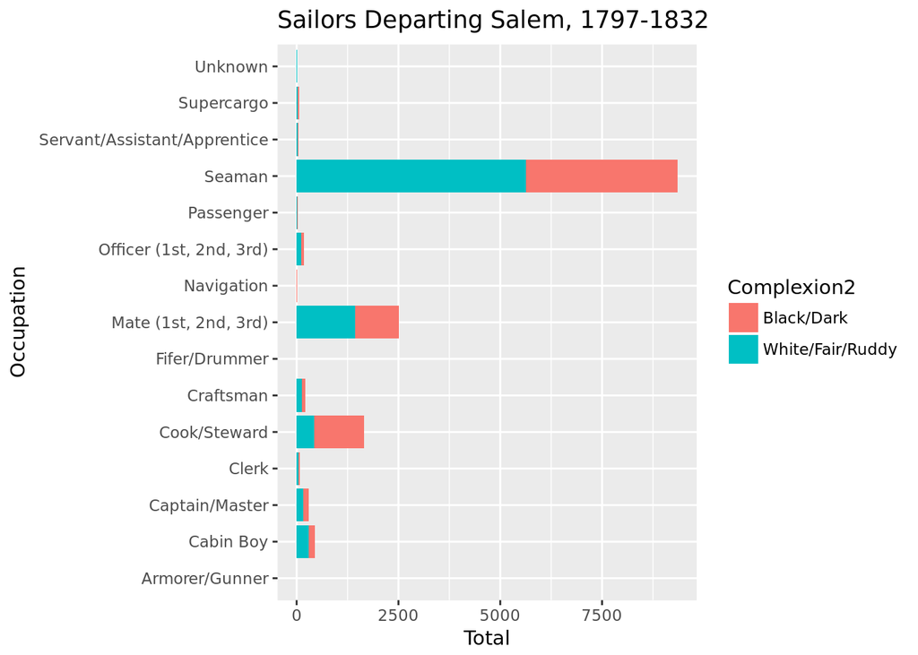

```r
salem_data_tidy_complexion2_position2_year_1797_1832 %>%
  filter(Complexion2 == "Black/Dark" | Complexion2 == "White/Fair/Ruddy") %>%
ggplot(aes(x = Position2, fill = Complexion2)) +
  geom_bar() + coord_flip() + labs(title = "Sailors Departing Salem, 1797-1832", x = "Occupation", y = "Total")
```

It is commonly known that many African-Americans in the early republic found employment as sailors. However, less studied are individuals from around the world who also found employment at sea. Salem’s role as a center of global trade facilitated the appeareance of people from around the world at its docks. These sailors had a complexion classified as “brown”, “yellow,” “olive” or “Indian” and are present a far more diverse wharf than simply black and white variance.

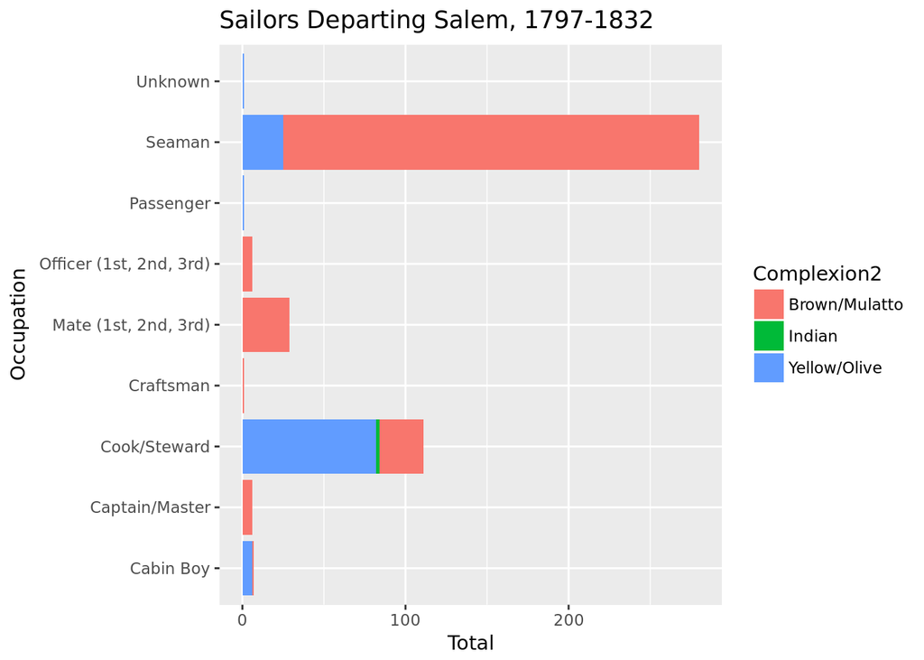

```r
salem_data_tidy_complexion2_position2_year_1797_1832 %>%
  filter(Complexion2 == "Brown/Mulatto" | Complexion2 == "Indian" | Complexion2 == "Yellow/Olive") %>%
ggplot(aes(x = Position2, fill = Complexion2)) +
  geom_bar() + coord_flip() + labs(title = "Sailors Departing Salem, 1797-1832", x = "Occupation", y = "Total")
```

shows a lot of yellow/olive were cooks, how did that compare with other races?

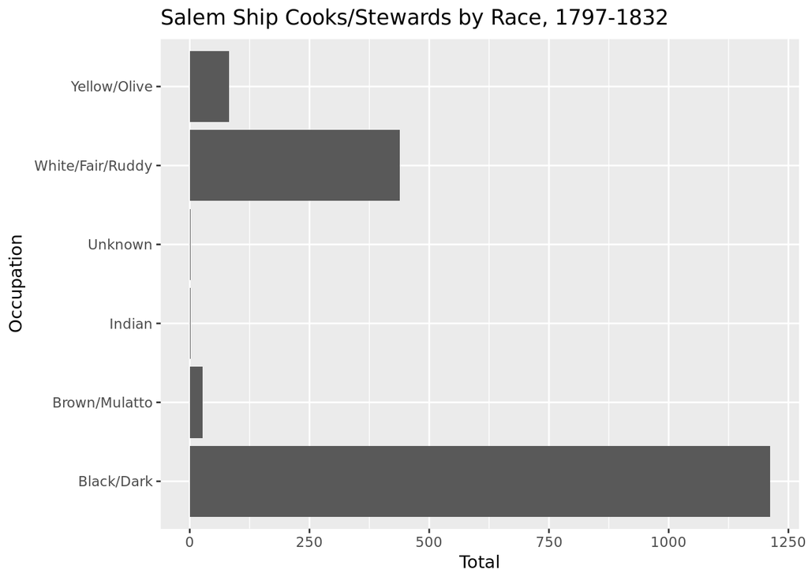

```r
salem_data_tidy_complexion2_position2_year_1797_1832 %>%
  filter(Position2 == "Cook/Steward") %>%
ggplot(aes(x = Complexion2)) +
  geom_bar() + coord_flip() + labs(title = "Salem Ship Cooks/Stewards by Race, 1797-1832", x = "Occupation", y = "Total")
```

Using more specific data set (seperates between cooks and stewards)

```r
Position3 <- data_frame(

  Position = c("1st Officer",
"2nd Officer",
"Seaman",
"Steward & Cook",
"Master",
"2nd Mate",
"Cook",
"First Officer",
"Clerk",
"First Mate",
"Second Mate",
"Carpenter",
"?",
"Steward",
"Mate",
"Second Officer",
"Orderly, Seaman",
"Third Mate",
"Boat Steerer",
"Ship Keeper",
"Steward & Seaman",
"Seaman, Sailmaker",
"Light Seaman",
"Orderly?,Seaman",
"Boy",
"Orderly/Seaman",
"cook",
"mate",
"Carpenter, Seaman",
"Light? Seamna",
"2nd officer",
"Third Officer",
"Harpoonsman",
"Cooper",
"Carpenter & Seaman",
"1st officer",
"2d officer",
"1st mate",
"2d mate",
"1st Mate",
"2d Mate",
"Seaman & Carpenter",
"carpenter & seaman",
"Ody?/Light Seaman",
"1 mate",
"2 mate",
"Ordindary Seaman",
"1st",
"2d",
"first officer",
"second officer",
"Clerk Seaman",
"Cook & Steward",
"3d mate",
"Seamen",
"First officer",
"Carpenter/Seaman",
"2d Officer",
"Mate 1st",
"Mate 2d",
"2 Mate",
"Ordinary seaman",
"Light seaman",
"Master?",
"Sec mate",
"secd Mate",
"1st Off",
"2d Off",
"Secd Mate",
"Cabin Boy",
"2nd mate",
"Third mate/Clerk",
"Armoure & Seaman",
"Hand",
"2nd Mate (crossed out)",
"St. Seaman",
"Officer",
"Boatswain",
"Ordinary",
"Supercargo",
"Captain",
"Seaman and clerk",
"1sr Mate",
"Stewards or Cook's Mate",
"Passenger",
"First mate",
"Cabin boy",
"`",
"Seaman and Cook",
"Lt Seaman",
"Second mate",
"Gunner",
"Clerk and seaman",
"Seaman?",
"Passenger?",
"Seaman and Carpenter",
"Carpenter and seaman",
"Ord Seaman",
"Captain's ?",
"Secont Mate",
"3rd Mate",
"Carpenter and Seaman",
"Sailor",
"Super Cargo",
"Purser",
"Beverly",
"Assistant",
"Apprentice",
"Young Seaman",
"Fresh Hand",
"Cook/Boy",
"Assistant [?]",
"Chief Mate",
"Clerk and Assistant",
"Norfolk",
"Clerk/Seaman",
"Ordinary Seaman",
"Gunner[?]",
"Fifer[?]",
"Greenhand",
"Ordinary[?]",
"Drummer",
"Mate\nMate",
"Cabinh Boy",
"Mariner",
"Second Mate`",
"Seaman/Cooper",
"Steward/Apprentice",
"Captain's Clerk",
"Seaman/Cook",
"Chf. Mate",
"Seaman/Carpenter",
"Sailmaker",
"Seaman\nSeaman",
"Joint Supercargo, w/Cap",
"Pilot",
"Supercargo and Passenge",
"Sail Maker",
"Cok",
"Second Mateq",
"Boy/Cook",
"Carp[enter",
"Apprentice.",
"First Officer[?]",
"Third Mate/Clerk",
"Fisrt Officer",
"Rank",
"Sail Ward",
"Stweard",
"Ist Mate",
"Assistant[?]",
"Servant",
"ond mate",
"? Mate",
"Boston",
"Mate?",
"Assistance",
"Third mate",
"3rd officer",
"Apprentice and Cook",
"Greenhand & Carpenter",
"Assistant & clerk",
"3rd mate",
"Carpenter & seaman",
"Super cargo",
"Cook & boy",
"Not given.",
"Apprentice to Captain",
"Sailing Master",
"Super cargo or consigne",
"Apprentice and Boy",
"1st mate?",
"Green hand",
"Sail-maker",
"Joint supercargo",
"Captain assistand",
"Factor",
"Apprentice seaman",
"Steward[?]",
"Seaman/Boy",
"1 officer",
"2 officer",
"Ordinary? Seaman",
"Seaman & carpenter",
"Chief mate",
"Cool",
"Stacker",
"Seaman-Cook",
"Seaman and Cooper",
"Seaman/Steward",
"Steward?",
"Cook?",
"Super cargp",
"1st maste",
"Seaman Ordy",
"Ordinary seamab",
"1sr mate",
"Seamna",
"Duxbury",
"Cabin passenger",
"Ordinary, Seaman",
"Cooper and Seaman",
"Supercargo[?]",
"3rd Mate/Clerk"),

Position3 = c("Officer (1st, 2nd, 3rd)",
"Officer (1st, 2nd, 3rd)",
"Seaman",
"Cook",
"Captain/Master",
"Mate (1st, 2nd, 3rd)",
"Cook",
"Officer (1st, 2nd, 3rd)",
"Clerk",
"Mate (1st, 2nd, 3rd)",
"Mate (1st, 2nd, 3rd)",
"Carpenter",
"Unknown",
"Steward",
"Mate (1st, 2nd, 3rd)",
"Officer (1st, 2nd, 3rd)",
"Orderly",
"Mate (1st, 2nd, 3rd)",
"Pilot/Steerer",
"Ship Keeper",
"Steward",
"Sailmaker",
"Seaman",
"Orderly",
"Cabin Boy",
"Orderly",
"Cook",
"Mate (1st, 2nd, 3rd)",
"Carpenter",
"Seaman",
"Officer (1st, 2nd, 3rd)",
"Officer (1st, 2nd, 3rd)",
"Harpoonsman",
"Cooper",
"Carpenter",
"Officer (1st, 2nd, 3rd)",
"Officer (1st, 2nd, 3rd)",
"Mate (1st, 2nd, 3rd)",
"Mate (1st, 2nd, 3rd)",
"Mate (1st, 2nd, 3rd)",
"Mate (1st, 2nd, 3rd)",
"Carpenter",
"Carpenter",
"Seaman",
"Mate (1st, 2nd, 3rd)",
"Mate (1st, 2nd, 3rd)",
"Seaman",
"Mate (1st, 2nd, 3rd)",
"Mate (1st, 2nd, 3rd)",
"Officer (1st, 2nd, 3rd)",
"Officer (1st, 2nd, 3rd)",
"Clerk",
"Cook",
"Mate (1st, 2nd, 3rd)",
"Seaman",
"Officer (1st, 2nd, 3rd)",
"Carpenter",
"Officer (1st, 2nd, 3rd)",
"Mate (1st, 2nd, 3rd)",
"Mate (1st, 2nd, 3rd)",
"Mate (1st, 2nd, 3rd)",
"Seaman",
"Seaman",
"Captain/Master",
"Mate (1st, 2nd, 3rd)",
"Mate (1st, 2nd, 3rd)",
"Officer (1st, 2nd, 3rd)",
"Officer (1st, 2nd, 3rd)",
"Mate (1st, 2nd, 3rd)",
"Cabin Boy",
"Mate (1st, 2nd, 3rd)",
"Mate (1st, 2nd, 3rd)",
"Armorer",
"Seaman",
"Mate (1st, 2nd, 3rd)",
"Seaman",
"Officer (1st, 2nd, 3rd)",
"Boatswain",
"Seaman",
"Supercargo",
"Captain/Master",
"Clerk",
"Mate (1st, 2nd, 3rd)",
"Steward",
"Passenger",
"Mate (1st, 2nd, 3rd)",
"Cabin Boy",
"Unknown",
"Cook",
"Seaman",
"Mate (1st, 2nd, 3rd)",
"Gunner",
"Clerk",
"Seaman",
"Passenger",
"Carpenter",
"Carpenter",
"Seaman",
"Captain/Master",
"Mate (1st, 2nd, 3rd)",
"Mate (1st, 2nd, 3rd)",
"Carpenter",
"Seaman",
"Supercargo",
"Purser",
"Unknown",
"Servant/Assistant",
"Apprentice",
"Seaman",
"Seaman",
"Cook",
"Servant/Assistant",
"Mate (1st, 2nd, 3rd)",
"Clerk",
"Unknown",
"Clerk",
"Seaman",
"Gunner",
"Fifer",
"Seaman",
"Seaman",
"Drummer",
"Mate (1st, 2nd, 3rd)",
"Cabin Boy",
"Seaman",
"Mate (1st, 2nd, 3rd)",
"Cooper",
"Apprentice",
"Clerk",
"Cook",
"Mate (1st, 2nd, 3rd)",
"Carpenter",
"Sailmaker",
"Seaman",
"Captain/Master",
"Pilot/Steerer",
"Supercargo",
"Sailmaker",
"Cook",
"Mate (1st, 2nd, 3rd)",
"Cook",
"Carpenter",
"Apprentice",
"Officer (1st, 2nd, 3rd)",
"Mate (1st, 2nd, 3rd)",
"Officer (1st, 2nd, 3rd)",
"Seaman",
"Sail Ward",
"Steward",
"Mate (1st, 2nd, 3rd)",
"Servant/Assistant",
"Servant/Assistant",
"Mate (1st, 2nd, 3rd)",
"Mate (1st, 2nd, 3rd)",
"Unknown",
"Mate (1st, 2nd, 3rd)",
"Servant/Assistant",
"Mate (1st, 2nd, 3rd)",
"Officer (1st, 2nd, 3rd)",
"Cook",
"Carpenter",
"Clerk",
"Mate (1st, 2nd, 3rd)",
"Carpenter",
"Supercargo",
"Cook",
"Unknown",
"Apprentice",
"Sailing Master",
"Supercargo",
"Apprentice",
"Mate (1st, 2nd, 3rd)",
"Seaman",
"Sailmaker",
"Supercargo",
"Servant/Assistant",
"Factor",
"Apprentice",
"Steward",
"Seaman",
"Officer (1st, 2nd, 3rd)",
"Officer (1st, 2nd, 3rd)",
"Seaman",
"Carpenter",
"Mate (1st, 2nd, 3rd)",
"Cook",
"Seaman",
"Cook",
"Cooper",
"Steward",
"Steward",
"Cook",
"Supercargo",
"Mate (1st, 2nd, 3rd)",
"Seaman",
"Seaman",
"Mate (1st, 2nd, 3rd)",
"Seaman",
"Unknown",
"Passenger",
"Seaman",
"Cooper",
"Supercargo",
"Mate (1st, 2nd, 3rd)"))
```

```r
salem_data_tidy_complexion2_position3_year_1797_1832 <- salem_data_tidy_complexion2_year_1797_1832 %>%
  left_join(Position3, by = "Position")
```

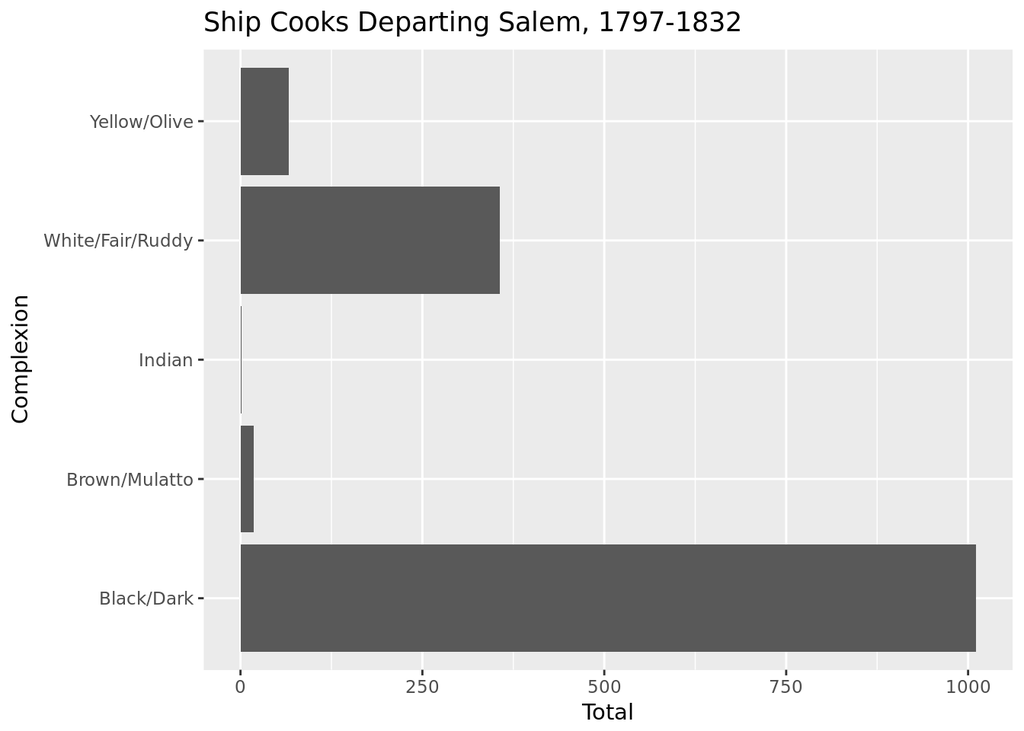

```r
salem_data_tidy_complexion2_position3_year_1797_1832 %>%
  filter(Position3 == "Cook") %>%
ggplot(aes(x = Complexion2)) +
  geom_bar() + coord_flip() + labs(title = "Ship Cooks Departing Salem, 1797-1832", x = "Complexion", y = "Total")
```

Let’s learn more about the Brown/Mulatto, Indian, and Olive/Yellow sailors.

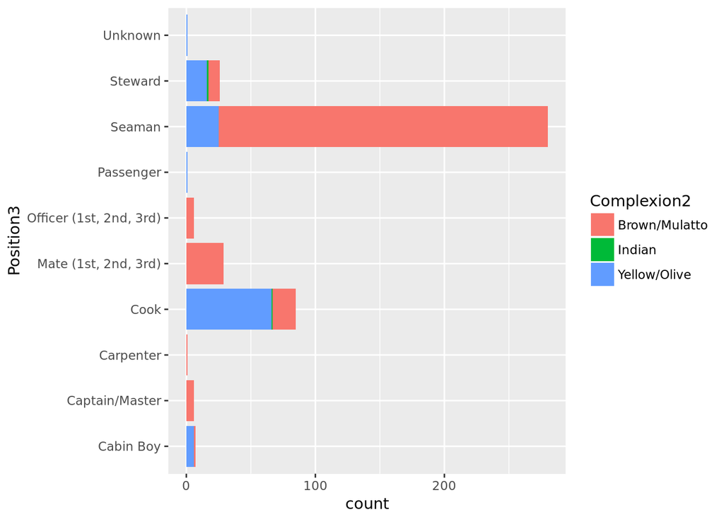

```r
salem_data_tidy_complexion2_position3_year_1797_1832 %>%
  filter(Complexion2 == "Brown/Mulatto" | Complexion2 == "Indian" | Complexion2 == "Yellow/Olive") %>%
  ggplot(aes(x = Position3, fill = Complexion2)) + geom_bar() + coord_flip()
```

```r
salem_data_world_connections_year_1797_1832 <- salem_data_tidy_complexion2_position3_year_1797_1832 %>%
  filter(Complexion2 == "Brown/Mulatto" | Complexion2 == "Indian" | Complexion2 == "Yellow/Olive")
```

442 entries (some could be doubles)

```r
unique(salem_data_world_connections_year_1797_1832$BirthPlace)
```

```
##   [1] "Manchester"               "Maryland"
##   [3] "Portsmouth, NH?"          "Java?"
##   [5] "Petersbury"               "Delaware"
##   [7] "Ipswich"                  "Portsmouth"
##   [9] "Baltimore"                "Boston"
##  [11] "New York"                 "Philadelphia"
##  [13] "Germantown"               "Orleans, Cape Cod"
##  [15] "Stockholm"                "Africa"
##  [17] "Nantucket"                "New Orleans"
##  [19] "Salem"                    "Bridgeport"
##  [21] "Canton"                   "USA"
##  [23] "Alexandria"               "Georgetown"
##  [25] "Marblehead"               "Newton, NJ"
##  [27] "Bath"                     "North Kingston"
##  [29] "Dunbarton, NH"            "Mississippi"
```

[output cut: 68 more lines]